# modelToolKitGuide

Matthew Davis

August 4, 2017

#### Predictive Model Preformance

Get predictive model prefomance by a catagory. Check to see if a model is preforming differently in by a group or catagory

```r
try(detach(package:modelToolKit, unload = TRUE))
library(modelToolKit)
library(rpart)
data(iris)
set.seed(2012)
fit<-rpart(Species~., iris)
km<-kmeans(iris[,1:4], 3)
preds<-predict(fit, iris, type = 'class')
obs<-iris[,'Species']
cats<-as.factor(km$cluster)
preformanceByCatagory(preds, obs, cats)
```

[output not shown]

#### Cluster Model Utilities

Assign new clusters using kmeans to new data

```r
table(predictKmeans(km, iris)[,'cluster'])
```

```
##
##  1  2  3
## 58 54 38
```

```r
x<-iris
x[,1]<-NA
table(predictKmeans(km, x)[, 'cluster'])
```

```
##
##  1  2  3
## 58 54 38
```

Find differences between data frames

```r
find2dfDiffs(iris[,1:4],iris[, 1:4]+.12)
```

```
## [1] "Sepal.Length" "Sepal.Width"  "Petal.Length" "Petal.Width"
## [1] "using cores :  4"
## [1] "dim output 4,3"
```

```
##                    pval  meanDf1  meanDf2
## Sepal.Length 0.21045878 5.843333 5.963333
## Sepal.Width  0.01773784 3.057333 3.177333
## Petal.Length 0.55650871 3.758000 3.878000
## Petal.Width  0.17378740 1.199333 1.319333
```

Find the optimal number of clusters

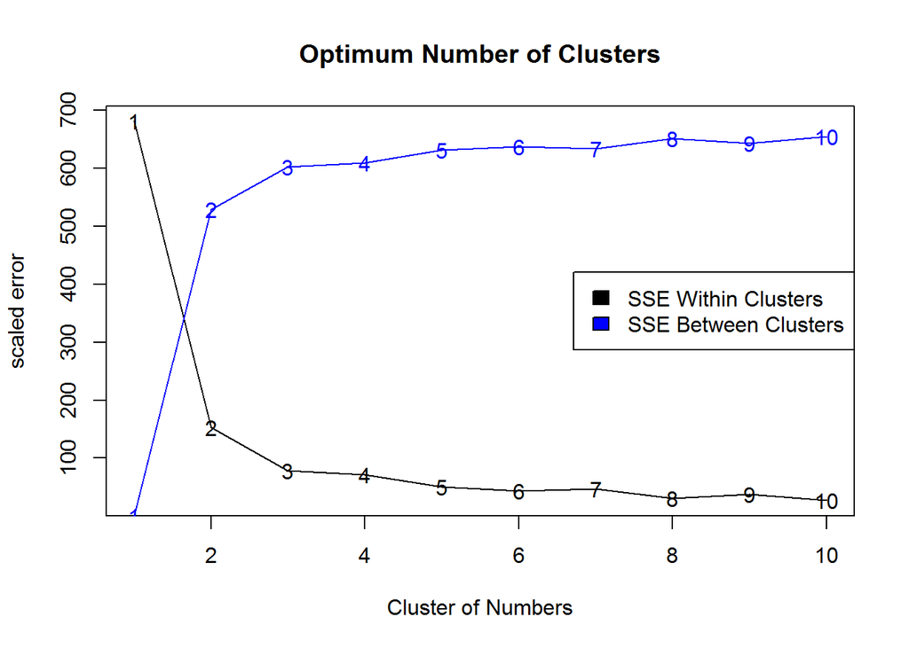

```
##                  within      between  k
## NumClusters1  681.37060 6.821210e-13  1
## NumClusters2  152.34795 5.290226e+02  2
## NumClusters3   78.85144 6.025192e+02  3
## NumClusters4   71.44525 6.099254e+02  4
## NumClusters5   49.85942 6.315112e+02  5
## NumClusters6   43.68323 6.376874e+02  6
## NumClusters7   46.99001 6.343806e+02  7
## NumClusters8   30.18455 6.511861e+02  8
## NumClusters9   37.52792 6.438427e+02  9
## NumClusters10  26.80989 6.545607e+02 10
```

```r
findClusters(iris[,1:4])
```

#### Data Frame and Factor Utlities

Find differences between two factors

```r
set.seed(12012)
x = as.factor(rep(c('a','b','c' , 'a'), 10))
y = as.factor(sample(c('a','b','c'), 30, replace = TRUE))
z<-factorDiffs(x,y)
z
```

```
##   lev      pval xMean     yMean
## 3   c 0.6276258  0.25 0.3333333
## 1   a 0.6463552  0.50 0.4000000
## 2   b 1.0000000  0.25 0.2666667
```

Find difference between all factors in two data frames

```r
size = 100
df1<-data.frame(x = as.factor(sample(c('a','b','c' ,'d'),size, replace = TRUE)),
                y = as.factor(sample(c('a','b','c','a') ,size, replace = TRUE)))

df2<-data.frame(x = as.factor(sample(c('a','b','c','c'),size, replace = TRUE)),
                y = as.factor(sample(c('a','b','c','b'), size, replace = TRUE)))

dataFrameFactDiffs(df1, df2)
```

```
##    lev         pval xMean yMean colName
## 4    d 1.274967e-05  0.21  0.00       x
## 3    c 4.266725e-03  0.26  0.48       x
## 2    b 4.291953e-01  0.32  0.26       x
## 1    a 5.321712e-01  0.21  0.26       x
## 11   a 2.882424e-07  0.59  0.21       y
## 21   b 1.211497e-03  0.25  0.50       y
## 31   c 4.252248e-02  0.16  0.29       y
```

```r
data1<-data.frame(x = as.factor(rep(c('a', 'b'), 10)),
                  y =  as.factor(rep(c('c', 'd'), 10)))

data2<-data.frame(x = as.factor(rep(c('a', 'b', 'GG'), 10)),
                  y =  as.factor(rep(c('c', 'FF','GG'), 10)))
str(levelMatcher(newData = data2, oldData = data1))
```

```
## [1] "num levs 2"
## $x
## [1] "a" "b"
##
## $y
## [1] "c" "d"
##
## 'data.frame':    30 obs. of  2 variables:
##  $ x: Factor w/ 2 levels "a","b": 1 2 NA 1 2 NA 1 2 NA 1 ...
##  $ y: Factor w/ 1 level "c": 1 NA NA 1 NA NA 1 NA NA 1 ...
```

##### Variable Contributions

Generate a predictive model for housing price over the mean housing price using the Sacramento data set inside caret. This model will be used to demonstrate logistic difference between observation functions

```r
library(caret)

data("Sacramento")
predVars<-c('city', 'beds', 'sqft','baths', 'type')
rd<-Sacramento[, predVars]
rd$class<-as.factor(ifelse(Sacramento$price > mean(Sacramento$price),1,0 ))
f<-formula(class~.)
fit<-glm(f, rd, family = 'binomial')

preds<-predict(fit, rd, type = 'response' )
```

check model preformance

```r
cutoff = .5
postResample(as.factor(ifelse(preds > cutoff,1,0)), rd$class)
```

```
##  Accuracy     Kappa
## 0.8540773 0.6873455
```

Find the different factor contributions between a reference observation and a test observation

```r
logisticDifference(fit,rd[2,predVars], mydata =  rd )
```

```
##          city          beds          sqft         baths          type
##   0.000000000   0.000000000  -0.133080397   0.006642649   0.000000000
## referencePred      testPred
##   0.201013681   0.070566601
```

Find the different factor contributions between a reference observation and a test data frame of observations

```r
x<-logisticDifferenceDf(model = fit,
                        testObs = rd[1:2,predVars],
                        refData = rd,
                        p = .4,
                        verbose = TRUE )
```

```
## [1] "no class name provided, random sampeling"
## [1] "num samples 373"
```

```r
print(x$output)
```

```
##                 city       beds       sqft       baths        type
## result.1 -0.06182013 0.08044562 -0.3165057 0.004511282 0.006704927
## result.2 -0.06182013 0.01543954 -0.2404427 0.004511282 0.006704927
##          referencePred   testPred
## result.1      0.387479 0.03482837
## result.2      0.387479 0.07056660
```

NA to unknow and NA to Value transform

```r
# create some data
mydata<-data.frame(x1 = rep(c('a', 'b', NA, 'c'),10),
                   x2 = rep(c('a', 'b', NA, 'c'),10),
                   y1 = rep(c(1,2,3,NA), 10),
                   y2 = rep(c(1,2,3,NA), 10))

NAtoValueDf(mydata, numVal = 0 , newLevName = 'unKnown' )
```

```
##         x1      x2 y1 y2
## 1        a       a  1  1
## 2        b       b  2  2
## 3  unKnown unKnown  3  3
## 4        c       c  0  0
## 5        a       a  1  1
## 6        b       b  2  2
## 7  unKnown unKnown  3  3
## 8        c       c  0  0
## 9        a       a  1  1
## 10       b       b  2  2
## 11 unKnown unKnown  3  3
## 12       c       c  0  0
## 13       a       a  1  1
## 14       b       b  2  2
```

[output cut: 26 more lines]